# White wine quality exploration by Lee Saldanha

# Multivariate Plots Section

Let’s first take a look at the histograms for the variables we found to have narrow interquartile ranges for wines of quality 9, and color them according to *quality*.

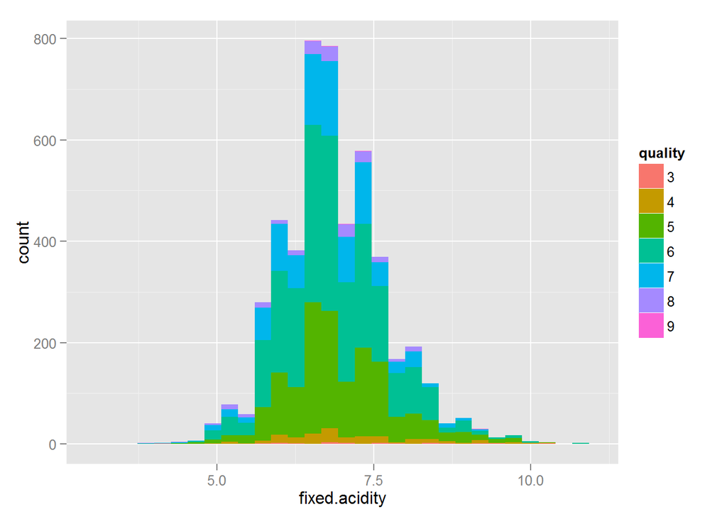

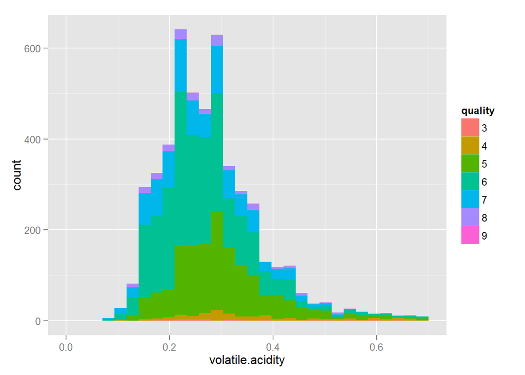

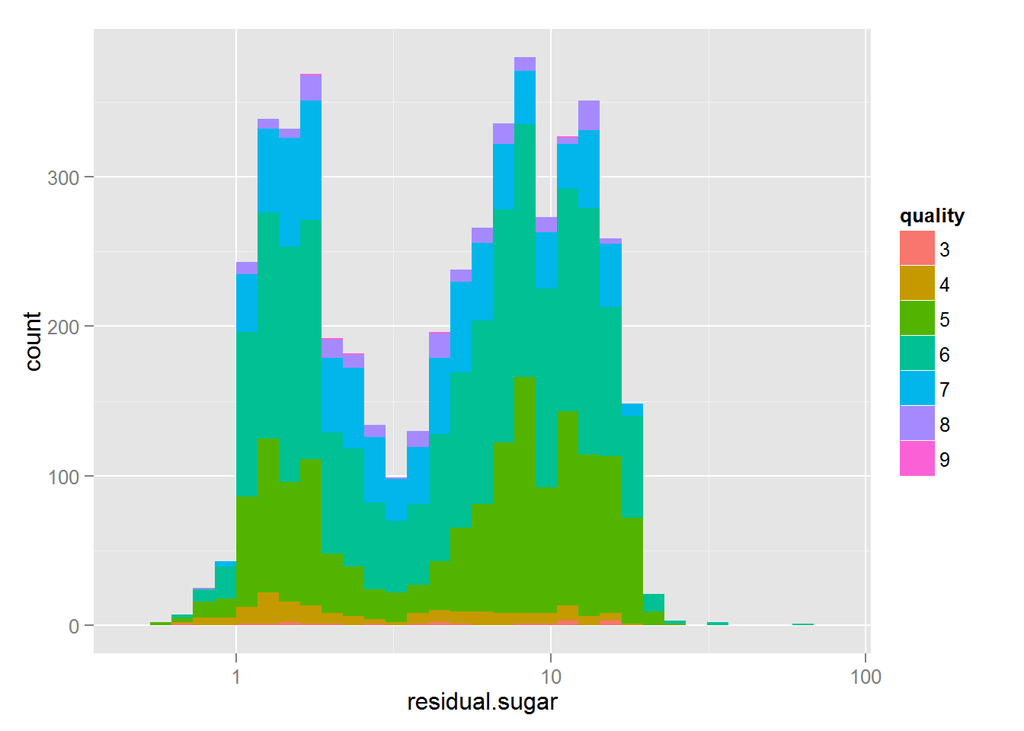

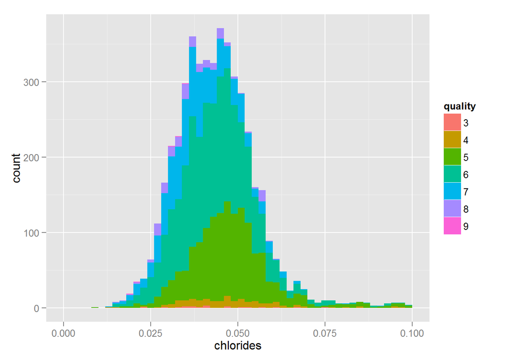

Some relationship can be seen in the above chart between fewer chlorides and superior quality.

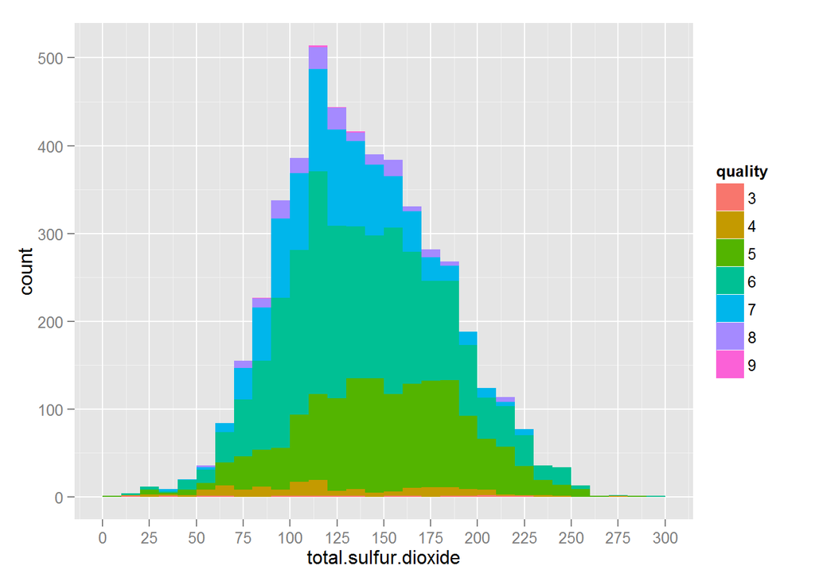

Some relationship can be seen in the above chart between less sulfur dioxide and superior quality.

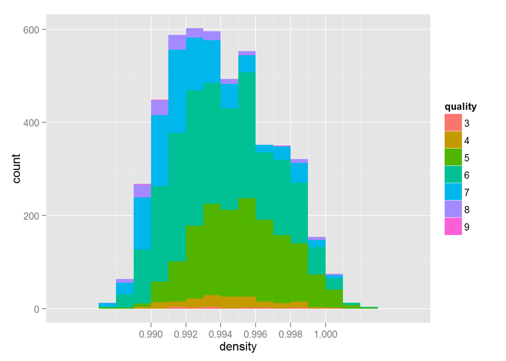

Some relationship can be seen in the above chart between less density and superior quality.

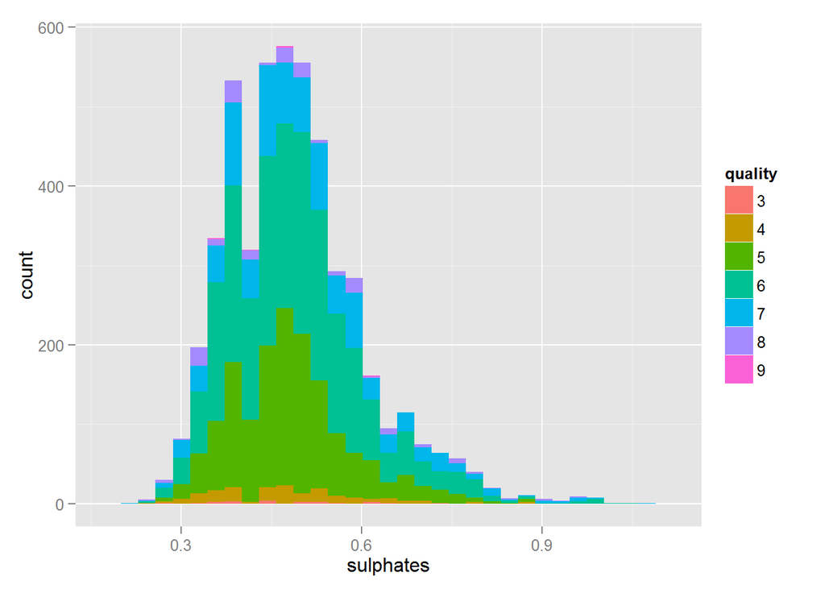

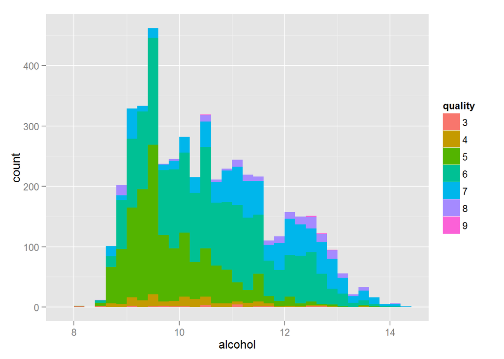

Still not very visually clear through these histograms only, but some trends can be seen, for example, with higher quality wines being found most commonly at lower density levels and higher alcohol values.

Now let’s look at multivariate scatterplots colored by *quality*.

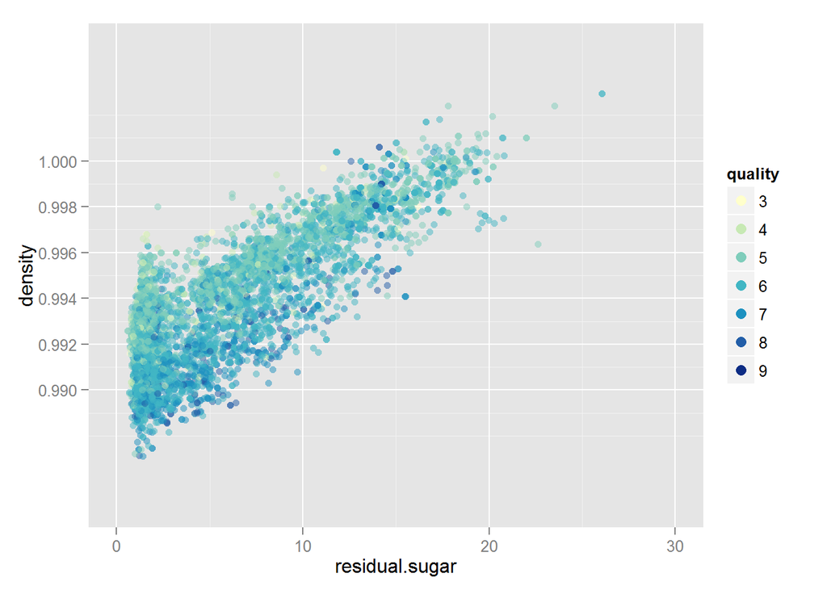

Here we can continue to see the relationship between *density* and *quality*, with superior quality wines (darker blue dots) being more present at lower density values in the y-axis.

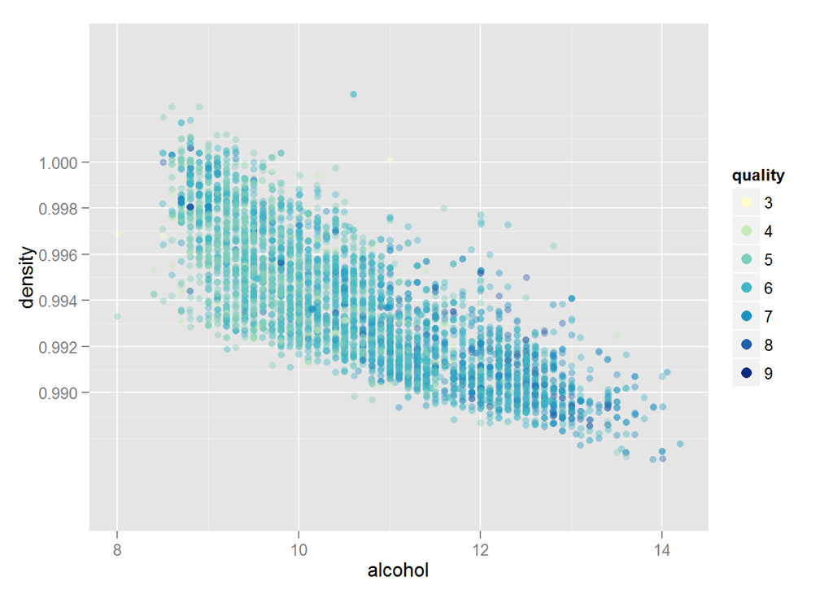

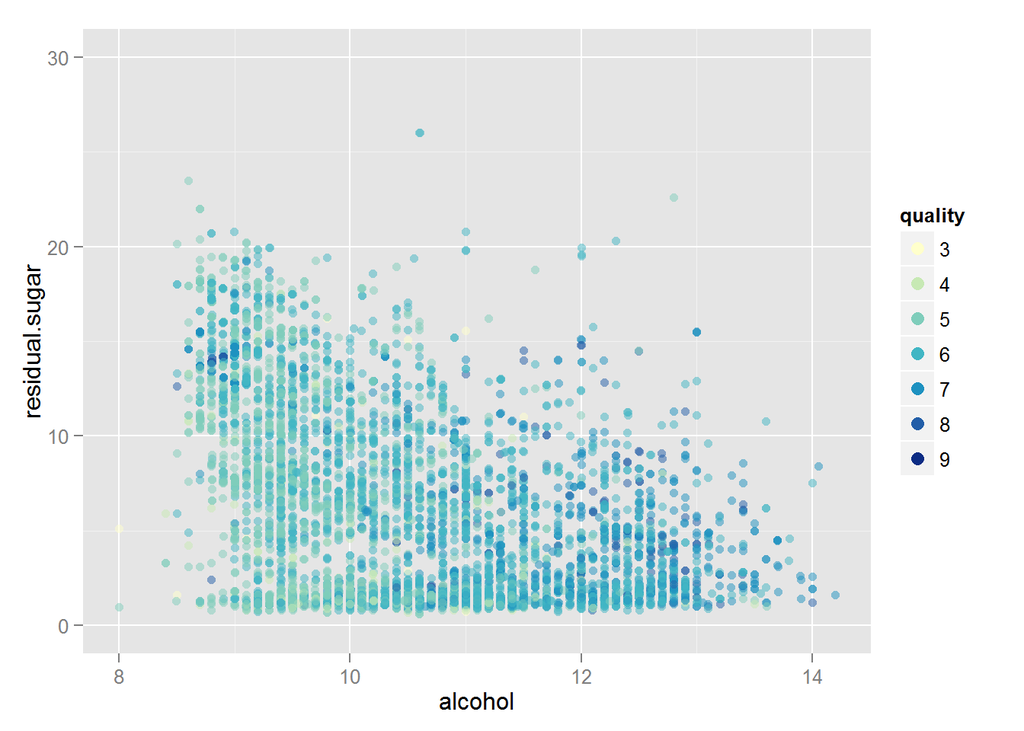

Having analyzed these variables, let’s now create a model. We will iteratively add variables to the model to see which variables contribute more to a higher R<sup>2</sup> value.

```
##
## Calls:
## m1: lm(formula = quality ~ fixed.acidity + residual.sugar, data = wines)
## m2: lm(formula = quality ~ fixed.acidity + residual.sugar + alcohol,
##     data = wines)
## m3: lm(formula = quality ~ fixed.acidity + residual.sugar + alcohol +
##     density, data = wines)
## m4: lm(formula = quality ~ fixed.acidity + residual.sugar + alcohol +
##     density + volatile.acidity, data = wines)
## m5: lm(formula = quality ~ fixed.acidity + residual.sugar + alcohol +
##     density + volatile.acidity + pH, data = wines)
## m6: lm(formula = quality ~ fixed.acidity + residual.sugar + alcohol +
##     density + volatile.acidity + pH + sulphates, data = wines)
## m7: lm(formula = quality ~ fixed.acidity + residual.sugar + alcohol +
##     density + volatile.acidity + pH + sulphates + free.sulfur.dioxide,
##     data = wines)
##
## ========================================================================================================
##                          m1          m2          m3          m4          m5          m6          m7
## --------------------------------------------------------------------------------------------------------
## (Intercept)            6.738***    2.547***   77.152***   52.814***   122.706***  157.469***  154.106***
##                       (0.103)     (0.155)    (14.178)    (13.739)     (17.428)    (18.131)    (18.100)
## fixed.acidity         -0.111***   -0.070***   -0.029      -0.047**      0.041*      0.065**     0.068***
##                       (0.015)     (0.013)     (0.015)     (0.015)      (0.020)     (0.020)     (0.020)
## residual.sugar        -0.015***    0.022***    0.049***    0.045***     0.074***    0.087***    0.083***
##                       (0.002)     (0.002)     (0.006)     (0.005)      (0.007)     (0.007)     (0.007)
## alcohol                            0.349***    0.260***    0.310***     0.223***    0.183***    0.193***
##                                   (0.010)     (0.020)     (0.019)      (0.023)     (0.024)     (0.024)
## density                                      -74.565***  -49.874***  -122.244*** -157.512*** -154.291***
##                                              (14.170)    (13.732)     (17.662)    (18.376)    (18.344)
## volatile.acidity                                          -2.081***    -1.995***   -1.943***   -1.888***
##                                                           (0.109)      (0.109)     (0.109)     (0.110)
## pH                                                                      0.672***    0.713***    0.694***
##                                                                        (0.104)     (0.104)     (0.103)
## sulphates                                                                           0.661***    0.629***
##                                                                                    (0.100)     (0.100)
## free.sulfur.dioxide                                                                             0.003***
##                                                                                                (0.001)
## --------------------------------------------------------------------------------------------------------
## R-squared                 0.021       0.206       0.211       0.265       0.272       0.278       0.282
## adj. R-squared            0.020       0.206       0.210       0.265       0.271       0.277       0.281
## sigma                     0.877       0.789       0.787       0.759       0.756       0.753       0.751
## F                        51.554     423.976     326.640     353.579     304.099     269.183     239.730
## p                         0.000       0.000       0.000       0.000       0.000       0.000       0.000
## Log-likelihood        -6303.567   -5788.827   -5775.006   -5599.094   -5578.196   -5556.387   -5544.144
## Deviance               3761.753    3048.657    3031.500    2821.384    2797.411    2772.609    2758.783
## AIC                   12615.134   11587.654   11562.012   11212.189   11172.392   11130.773   11108.288
## BIC                   12641.121   11620.137   11600.991   11257.665   11224.365   11189.243   11173.254
## N                      4898        4898        4898        4898        4898        4898        4898
## ========================================================================================================
```

# Multivariate Analysis

### Talk about some of the relationships you observed in this part of the investigation. Were there features that strengthened each other in terms of looking at your feature(s) of interest?

In the histograms colored by quality, trends can be seen with higher quality wines having *volatile.acidity* values lower than 0.3, *chlorides* values between 0.025 and 0.05, *total.sulfur.dioxide* values between 90 and 160, *density* values between 0.99 and 0.995, and *alcohol* values greater than 10.5, as initially indicated by the quality boxplots.

In the scatterplots, the relationship between some variables (other than *quality*) becomes clearer. In the first scatterplot, it is visible that higher quality wines are more commonly found at lower values of *residual.sugar* (less than 10) and also lower *density* (less than 0.994). The second scatterplot follows the same logic as the previous one, with the darker blue dots (higher quality wines) being more commonly found for *density* values of 0.994 and lower, and for *alcohol* values of 11 and above. The last scatterplot is a combination of the previous ones, where most higher quality wines can be found for lower values of *residual.sugar* and higher values of *alcohol*.

### Were there any interesting or surprising interactions between features?

The relationship between more volume of alcohol and less density is personally a surprising finding, despite being already described in the [White Wine Quality information document](https://s3.amazonaws.com/udacity-hosted-downloads/ud651/wineQualityInfo.txt).

### OPTIONAL: Did you create any models with your dataset? Discuss the strengths and limitations of your model.

A linear model was created using several variables, which were added iteratively to check the effect that each had on the results. The selected variables account for only 28.2% of the variance in the quality of wines. The ones that contribute most to this value of R<sup>2</sup> are *alcohol* and *volatile.acidity*, which alone account for an R<sup>2</sup> = 0.24.

This model using 8 variables and having an R<sup>2</sup> value of only 0.282 is very limited, but this appears to be due to the nature of the dataset. The quality score is based on the sensory evaluation of 3 wine experts and, as explained in the [White Wine Quality information document](https://s3.amazonaws.com/udacity-hosted-downloads/ud651/wineQualityInfo.txt), support vector machine is the model that achieves the best results according to the dataset authors. As we proceed to Project 4 and learn about machine learning, it could be interesting to test a support vector machine model with this white wines dataset and see how it improves the results.

# Final Plots and Summary

### Plot 1 - Histogram of wines by quality

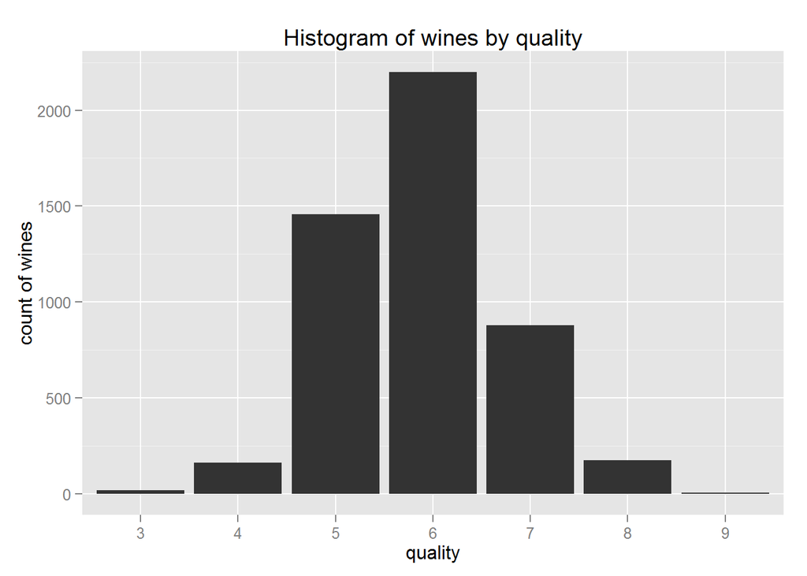

### Description

The distribution of wines by quality is rather normal, with the vast majority being of quality 5 to 7.

### Plot 2 - Histogram of wines by alcohol and quality

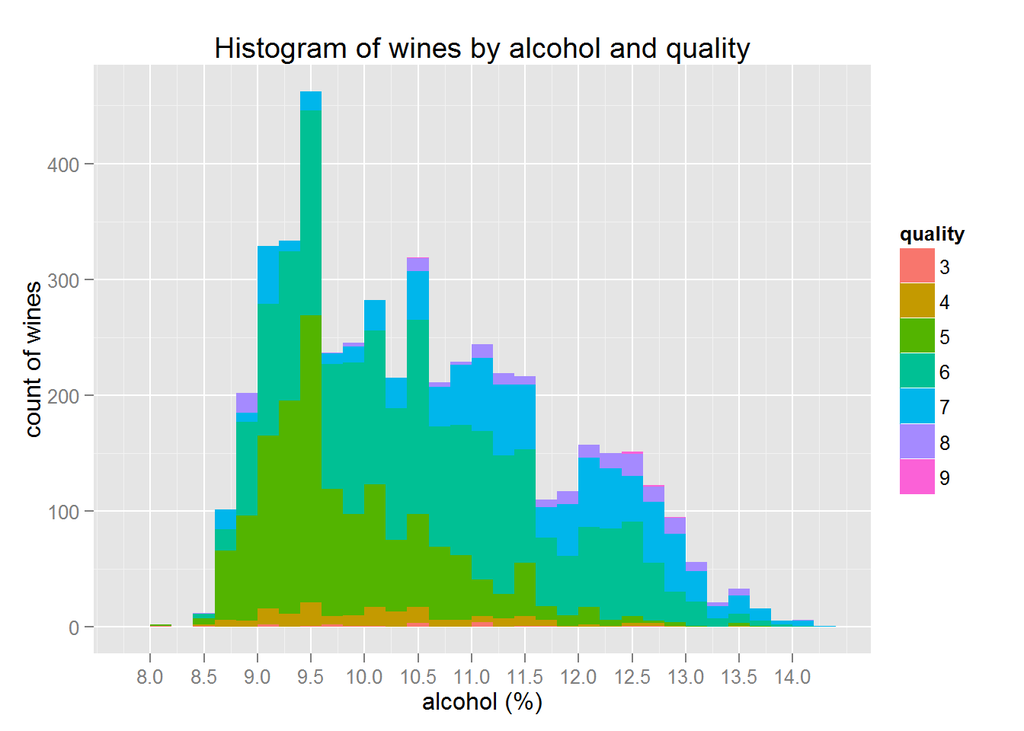

### Plot 3 - Scatterplot of wine quality by residual sugar and density

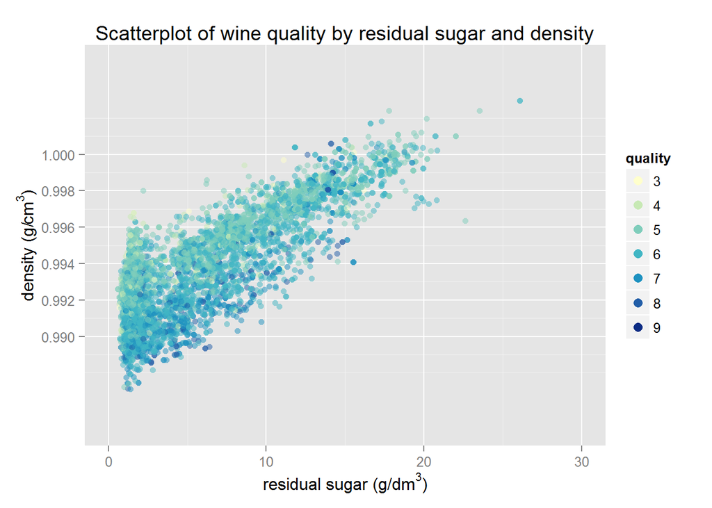

### Description

This scatterplot shows that, for the same levels of residual sugar (x-axis constant), higher quality wines tend to have lower density. This can be seen as “stripes” in the scatterplot (variation in the y-axis holding the values in the x-axis constant), with the top of the curve being mostly composed by lighter blue dots (wine quality 6 or less) and the bottom of the curve being mostly darker blue (wine quality 7 or more). Another obvious conclusion from this scatterplot is that density increases as the residual sugar also increases.

# Reflection

With the first plotted histogram (count of wines by quality), it already became clear that this white wines dataset was not balanced and contained many more regular wines (of quality 5 to 7) than poor or excellent ones. Wines of quality 5 to 7 make up over 92.5% of the total and this unbalanced distribution could have an impact on the analysis conducted. Also, the dataset has 11 input variables, which right from the beginning made me wonder whether all of them would be relevant or not for the analysis. I noticed some variables are correlated or dependent on each other, for example, *free.sulfur.dioxide* and *total.sulfur.dioxide*, and *density*, *residual.sugar* and *alcohol*. This is also mentioned in the [White Wine Quality information document](https://s3.amazonaws.com/udacity-hosted-downloads/ud651/wineQualityInfo.txt) and is one of the reasons why I tested most if not all of the variables when creating the linear model.